# Teaching Statistical Computing with R and Python

Susan Vanderplas

2025-08-09

## Outline

- How to accidentally write a textbook
- Design Decisions
- Teaching R and Python together
- Conclusions

Textbook Link

Slides Link

# How to Accidentally Write A Textbook

[figure not shown]

## In the beginning… Spring 2020 ⛈️🌏

Teaching Computing Tools for Statistics (Grad) in Fall

- I have to teach R AND SAS?
  - Oh 💩, I have to learn SAS
- Fall 2020 uncertainty ☣️🦠😷
  - Flipped classroom = more flexibility? 🤞
- Outside-class material: Videos or book(s)?
  - What book is the SAS equivalent of R4DS?

🤔 Writing a textbook > editing videos, right?

[figure not shown]

[figure not shown]

My 2020 world-on-fire coping mechanism

## Spring 2021-22

- Assigned to develop new undergraduate computing courses in Spring 2022
  - in R and Python 🐍
  - Oh 💩, I have to learn Python 😱
- New book w/ grad text in undergrad-sized chunks
- Add Python 😬, Remove SAS 😌
- Maintaining two textbooks is hard work!

## Summer 2022 - Quarto!

- Plan: Combine the textbooks
  - multiple chapters/wk for grad students 📚
  - single chapter/wk for undergrads 📗
  - Only maintain one version 🥱
- Convert to Quarto
- Make use of tabset panels 😍
- R
- Python

```r
# R code
```

```python
# Python code
```

## Since Summer 2022

- Add chapters for additional undergrad computing courses
- Update chapters: clarity, package updates, etc.
- This summer:
  - Title II compatibility checks
  - Graduate student editing
  - New chapters - advanced stat computing

# Design Decisions

## Initial Philosophy

- Include all of the bad jokes 😜, comics 💬, and digressions 🐇 from lectures
- GIFs can explain better than words (sometimes)
- Show the same techniques in both languages
  - focus on the operation, not syntax
- Center importance of reproducibility  
  (with SAS? 😅 `SASMarkdown`)
- Opinionated Tool Selection

## Sketchy Diagrams

[figure not shown]

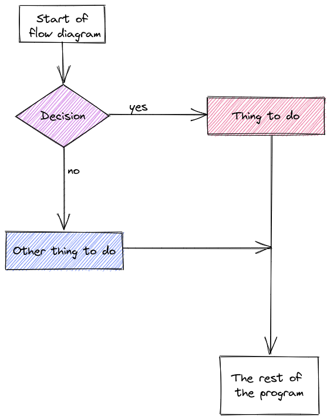

## Examples and Activities

**Guess and Check**

What will this code output?

- Pseudocode
- Sketch
- R
- Python

```
myfun = function() x + 1

x = 14

myfun()

x = 20

myfun()
```

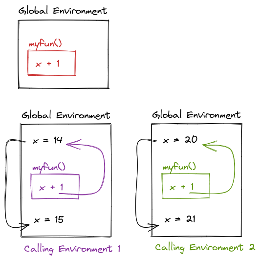

The state of the global environment at the time the function is called (that is, the state of the calling environment) can change the results of the function

```r
myfun <- function() {
  x + 1
}

x <- 14

myfun()
```

```
[1] 15
```

```r
x <- 20

myfun()
```

```
[1] 21
```

```python
def myfun():
  return x + 1


x = 14

myfun()
```

```
15
```

```python
x = 20

myfun()
```

```
21
```

## Additional Reproducibility

- Without SAS, 👼👿  
  build the textbook via GitHub Actions?
  - LOTS of package deps in R and python 😱😵‍💫
  - Better reproducibility, more of a pain in the 🍑
  - Dependency caching is a lifesaver (most of the time)

## Information Overload 🤯🫣

- It’s hard to strike a balance between
  - amount of code/output
  - centering important content

[figure not shown]

## In Practice

- Students with a non-English dominant language vastly preferred the textbook to lectures
  - Sometimes supplemented with R4DS translations ❤️
- Some spend way more time outside of class ⏲️
  - But, they would have been lost in a lecture-format class
- Reading quizzes are essential to remind students to look at the book before class
  - Not a universally successful motivator

Overall, a reasonable success!

# Teaching R and Python Together

[figure not shown]

Image generated by ChatGPT and modified

## Why?

- 🔬 Focus on concepts (look up syntax 🔍)
- Data science/stat languages change! (Julia? JavaScript? Python? Ruby?)
- Critical Skills:
  - 📖 Reading & 🧠 understanding documentation
  - Knowing how to look for help 🆘

## How?

- Assignments
  - basic tasks in both languages 👶
  - harder tasks 🧑 – pick a language
  - Bonus points (sometimes) for using both languages 🧑‍🦳
- 2 Languages keep advanced students engaged  
  Others focus on mastering one language + concepts
- Exams
  - Use either language for code
  - Focus on concepts/sketching/planning

## Student Reactions

- Initial frustration 😧 - syntax is hard in one language!
  - Plus quarto, markdown, git… it’s a lot! 🧩
- Motivation: internships and experience 🧑‍💼 💼
- Some appreciation for learning “why”, not “what” to do
- Textbook helps anchor concepts (visual memory 👀🧠)
- Like being able to comment via giscus 🗨️
  - Relatively quick resonse time
  - Adventurous students submit PRs to fix typos

# Roadmap

## Additional Chapters & Updates

- Interactive Graphics beyond Shiny/Plotly
- Databases 🦆 🏹
- “Big” data strategies
- Add `polars` 🐻‍❄️ content to supplement `pandas` 🐼

## Other Cool Stuff I’d love to get to

- `webR` and `PyScript` integration
  - Allow direct interactivity instead of just showing code + solutions
- Audiobook format with quarto.audiobook (2024 GSoC Project)
- Using JavaScript to create a TL;DR switch
  - hide long explanations
  - focus on the basic info
  - reduce info overload 😵‍💫 ️🏋️‍♀️

# Wrapping Up

## Important Sources

- Allison Horst’s *amazing* artwork
- comics - XKCD and Julia Evans

Books

- R for Data Science
- Advanced R
- Git and GitHub for the useR - Jenny Bryan
- [Python for Everyone](https://www.py4e.com/) - Charles Severance
- Python for Data Analysis - Wes McKinney
- Python Data Science Handbook - Jake Vanderplas

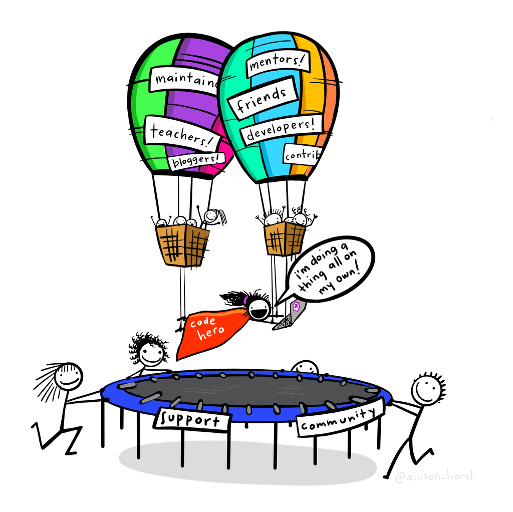

Image by Allison Horst. [Source](https://allisonhorst.com/everything-else)